# PNUT: Personalized Network Utility Toolkit

Hanjoo Kim

2026-03-05

[figure not shown]

Summary

PNUT derives **personalized (individual-level) network features** from questionnaire item responses to enable **Network-Augmented Machine Learning Utility (NAMU)**. Specifically, PNUT converts each participant’s item-response profile into an individualized symptom co-activation network and extracts network-informed predictors (e.g., node strength, pairwise edge weights, and graph-level connectivity summaries such as binary/weighted density). These features can be used alongside conventional predictors in machine learning pipelines to incorporate both symptom severity and symptom–symptom structure into NAMU-based modeling.

For additional details on the NAMU framework and its rationale, please refer to the following paper:  
Kim, H., Yocum, A., McInnis, M., & Sperry, S. H. (2025, September). Predicting suicidal ideation from depression screening data: A network-augmented machine learning approach. In revision at the *Journal of Affective Disorders*. https://doi.org/10.31234/osf.io/rqyvx_v2

# 1 Project Setup

## 1.1 Load Required Packages

```r
library(dplyr)
library(tidyr)
library(ggplot2)
```

## 1.2 Set project parameters

To run PNUT, edit the YAML header:

- `params: input_file` - path to your CSV
- `params: id_col` - participant ID column name
- Choose ONE:
  - `params: item_cols` - list of item column names (recommended), or
  - `params: item_regex` - pattern to select item columns automatically

If both are provided, PNUT uses `item_cols`.

```r
p <- params

input_file <- p$input_file
input_file_has_headers <- p$input_file_has_headers
id_col <- p$id_col
item_cols <- p$item_cols
item_regex <- p$item_regex
na_action <- p$na_action
scale_items <- p$scale_items
binary_edge_rule <- p$binary_edge_rule
output_file <- p$output_file
show_data_glimpse <- p$show_data_glimpse
histogram_bins <- p$histogram_bins

cat("input_file:", input_file, "\n")
```

```
## input_file: data/combined_data.csv
```

## 1.3 Global functions

```r
adj_outer <- function(x){A<-outer(x,x,"*");diag(A)<-0;A}
strength_from_A <- function(A) rowSums(A)
edge_vector_from_A <- function(A) A[upper.tri(A)]
connectivity_summaries <- function(x,A,rule=c("A_gt_0","x_gt_0")){
  rule<-match.arg(rule);v<-A[upper.tri(A)]
  if(rule=="A_gt_0") binary_prop<-mean(v>0)
  else{M<-outer(x>0,x>0,"&");diag(M)<-FALSE;binary_prop<-mean(M[upper.tri(M)])}
  c(BinaryDensity=binary_prop,WeightedDensityMean=mean(v),WeightedDensitySum=sum(v))
}
impute_mean <- function(v){v[is.na(v)]<-mean(v,na.rm=TRUE);v}
impute_median <- function(v){v[is.na(v)]<-median(v,na.rm=TRUE);v}
```

## 1.4 Load data sets

Put your CSV in the same folder as this `.Rmd` (recommended) or in `data/`. Update YAML: `params: input_file`, `params: id_col`, and `params: item_cols` (or `item_regex`).  
If the file is not found, PNUT generates a **synthetic demo dataset** (demo/testing only; not for interpretation). In this template, `DPQ010`–`DPQ080` illustrate PHQ-8 items.

```r
if(file.exists(input_file)){
  dat <- read.csv(input_file, header=input_file_has_headers)
} else {
  set.seed(1)
  dat <- data.frame(
    SEQN=1:120,
    DPQ010=sample(0:3,120,TRUE),
    DPQ020=sample(0:3,120,TRUE),
    DPQ030=sample(0:3,120,TRUE),
    DPQ040=sample(0:3,120,TRUE),
    DPQ050=sample(0:3,120,TRUE),
    DPQ060=sample(0:3,120,TRUE),
    DPQ070=sample(0:3,120,TRUE),
    DPQ080=sample(0:3,120,TRUE)
  )
  id_col <- "SEQN"
  if(is.null(item_cols)||length(item_cols)==0)
    item_cols <- c("DPQ010","DPQ020","DPQ030","DPQ040","DPQ050","DPQ060","DPQ070","DPQ080")
}

if(is.null(item_cols)||length(item_cols)==0){
  if(is.null(item_regex)) stop("Provide item_cols or item_regex.")
  item_cols <- names(dat)[grepl(item_regex,names(dat))]
}

stopifnot(id_col %in% names(dat))
stopifnot(all(item_cols %in% names(dat)))

df <- dat[,c(id_col,item_cols)]
df[item_cols] <- lapply(df[item_cols], function(x){
  if(is.factor(x)) x <- as.character(x)
  suppressWarnings(as.numeric(x))
})

if(isTRUE(scale_items)) df[item_cols] <- as.data.frame(scale(as.matrix(df[item_cols])))

if (na_action == "listwise") {
  df_clean <- na.omit(df)

} else if (na_action == "mean_impute") {
  df_clean <- df
  for (cc in item_cols) {
    df_clean[[cc]] <- impute_mean(df_clean[[cc]])
  }

} else if (na_action == "median_impute") {
  df_clean <- df
  for (cc in item_cols) {
    df_clean[[cc]] <- impute_median(df_clean[[cc]])
  }

} else {
  stop("Invalid na_action: use listwise / mean_impute / median_impute")
}

if(isTRUE(show_data_glimpse)) dplyr::glimpse(df_clean)
```

```
## Rows: 120
## Columns: 9
## $ SEQN   <int> 1, 2, 3, 4, 5, 6, 7, 8, 9, 10, 11, 12, 13, 14, 15, 16, 17, 18, …
## $ DPQ010 <dbl> 0, 3, 2, 0, 1, 0, 2, 2, 1, 1, 2, 2, 0, 0, 0, 1, 1, 1, 1, 2, 0, …
## $ DPQ020 <dbl> 1, 3, 2, 2, 3, 2, 0, 1, 1, 0, 2, 2, 1, 2, 1, 0, 3, 1, 3, 0, 3, …
## $ DPQ030 <dbl> 3, 3, 2, 1, 0, 3, 2, 3, 0, 1, 0, 3, 2, 0, 0, 2, 3, 2, 0, 3, 3, …
## $ DPQ040 <dbl> 2, 1, 0, 3, 3, 0, 3, 1, 2, 2, 2, 2, 1, 3, 0, 3, 1, 0, 0, 2, 1, …
## $ DPQ050 <dbl> 3, 0, 2, 2, 2, 3, 1, 0, 0, 1, 2, 3, 2, 1, 3, 2, 0, 2, 3, 3, 2, …
## $ DPQ060 <dbl> 2, 0, 1, 0, 0, 3, 2, 1, 1, 1, 0, 2, 2, 2, 3, 1, 1, 1, 0, 3, 2, …
## $ DPQ070 <dbl> 0, 1, 3, 3, 1, 0, 3, 2, 2, 1, 0, 0, 0, 3, 0, 1, 1, 2, 2, 3, 3, …
## $ DPQ080 <dbl> 3, 3, 1, 2, 0, 3, 0, 2, 3, 2, 1, 0, 0, 1, 3, 0, 1, 1, 1, 3, 1, …
```

# 2 Derive Personalized Network Features

If `scale_items = TRUE`, all network features are computed from standardized item scores (mean 0, SD 1).

## 2.1 Strength centrality

```r
p <- length(item_cols)
strength_names <- paste0("Strength_", item_cols)
n_used <- nrow(df_clean)
ids <- df_clean[[id_col]]

strength_mat <- matrix(
  NA_real_, nrow = n_used, ncol = p,
  dimnames = list(NULL, strength_names)
)

for (i in seq_len(n_used)) {
  x <- as.numeric(df_clean[i, item_cols])
  A <- adj_outer(x)
  strength_mat[i, ] <- strength_from_A(A)
}

strength_df <- cbind(
  setNames(data.frame(ids), id_col),
  as.data.frame(strength_mat)
)
```

*Note.* For each participant, PNUT constructs an individual co-activation matrix $A$ using the outer product of item responses, $A_{jk} = x_j x_k$, with the diagonal set to 0 ($A_{jj}=0$).  
Strength for item $j$ is then computed as the row-sum of $A$: $\mathrm{Strength}_j = \sum_{k \ne j} A_{jk}$.  
This is a within-person, response-derived connectivity feature, not a group-estimated correlation/partial-correlation network parameter.

## 2.2 Edge weights

```r
pairs_idx <- combn(seq_along(item_cols), 2)
edge_names <- paste0("EW_", item_cols[pairs_idx[1,]], "_", item_cols[pairs_idx[2,]])

edge_mat <- matrix(NA_real_, nrow = n_used, ncol = ncol(pairs_idx),
                   dimnames = list(NULL, edge_names))

for (i in seq_len(n_used)) {
  x <- as.numeric(df_clean[i, item_cols])
  A <- adj_outer(x)
  edge_mat[i, ] <- apply(pairs_idx, 2, function(v) A[v[1], v[2]])
}

edges_df <- cbind(
  setNames(data.frame(ids), id_col),
  as.data.frame(edge_mat)
)
```

*Note.* For each participant, PNUT constructs an individual co-activation matrix $A$ using the outer product of item responses, $A_{jk} = x_j x_k$, with the diagonal set to 0.  
The edge weight between items $j$ and $k$ is then defined as the corresponding off-diagonal entry of $A$: $\mathrm{EW}_{jk} = A_{jk} = x_j x_k$ (reported for unique pairs only, i.e., the upper triangle of $A$).  
These edge weights are within-person, response-derived co-activation features, not correlation/partial-correlation network parameters estimated from group-level data.

## 2.3 Density

BinaryDensity counts the fraction of “active” item pairs; `binary_edge_rule` controls whether “active” means co-activation > 0 (`A_gt_0`) or both items > 0 (`x_gt_0`).

```r
summary_mat <- matrix(NA_real_, nrow=n_used, ncol=3,
                      dimnames=list(NULL,c("BinaryDensity","WeightedDensityMean","WeightedDensitySum")))
for(i in seq_len(n_used)){
  x <- as.numeric(df_clean[i,item_cols])
  A <- adj_outer(x)
  summary_mat[i,] <- connectivity_summaries(x,A,rule=binary_edge_rule)
}
summary_df <- cbind(
  setNames(data.frame(ids), id_col),
  as.data.frame(summary_mat)
)
```

*Note.* PNUT summarizes each participant’s co-activation matrix $A$ into graph-level connectivity features. Using the unique edge set (upper triangle of $A$), PNUT reports: 1) BinaryDensity: the proportion of edges that are nonzero (default rule: $A_{jk} > 0$). This corresponds to a count-based connectivity notion (i.e., how many item pairs are “active”) used in the NAMU paper. 2) WeightedDensityMean: the mean of the edge weights, $\frac{1}{m}\sum_{j<k} A_{jk}$. 3) WeightedDensitySum: the sum of the edge weights, $\sum_{j<k} A_{jk}$.

These density summaries are within-person, response-derived co-activation features, not group-estimated correlation/partial-correlation network parameters.

## 2.4 Merge features

```r
features_df <- strength_df %>%
  left_join(edges_df, by=setNames(id_col,id_col)) %>%
  left_join(summary_df, by=setNames(id_col,id_col))

out <- dat %>% left_join(features_df, by=setNames(id_col,id_col))
```

# 3 Quality checks

```r
dup_n <- sum(duplicated(out[[id_col]]))
na_id <- sum(is.na(out[[id_col]]))
miss_cols <- c(colnames(strength_mat),colnames(edge_mat),colnames(summary_mat))
miss_rates <- out %>% summarize(across(all_of(miss_cols), ~mean(is.na(.)))) %>% t()
```

# 4 Visualization

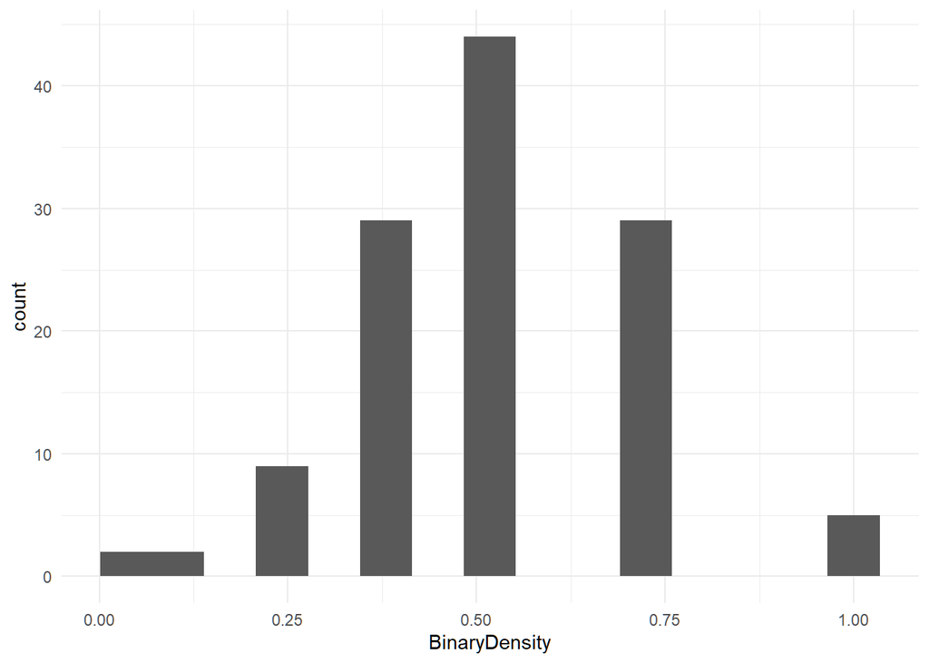

```r
ggplot(out, aes(x=BinaryDensity)) +
  geom_histogram(bins=histogram_bins) +
  theme_minimal()
```

# 5 Output

```r
out_dir <- dirname(output_file)
if (!dir.exists(out_dir)) dir.create(out_dir, recursive = TRUE)

write.csv(out, file = output_file, row.names = FALSE)
cat("Saved:", output_file, "\n")
```

```
## Saved: output/PNUT_outputs.csv
```

**Citation:** Kim, H. (2026). *PNUT: Personalized Network Utility Toolkit*. GitHub repository.